# Influencia de la actividad fisica, horas de estudio y horas de sueño sobre el rendimiento academico

# Objetivo general:

Analizar de manera exhaustiva la relación entre diversos hábitos de vida estudiantil principalmente la actividad física semanal, las horas de estudio y las horas de sueño y su impacto en el rendimiento académico, empleando técnicas estadísticas descriptivas y analíticas que permitan identificar tendencias, asociaciones y posibles interacciones entre estas variables. Este objetivo busca establecer si estos factores contribuyen de manera significativa al desempeño académico, así como comprender la magnitud y dirección de sus efectos, con el fin de aportar evidencia útil para la toma de decisiones orientadas a mejorar el bienestar y el desempeño académico de los estudiantes.

## Objetivos especificos:

- 1: Identificar los patrones generales de distribución y comportamiento de la actividad física semanal, las horas de estudio y las horas de sueño en la población universitaria analizada.
- 2: Evaluar la relación individual entre cada uno de los hábitos de vida seleccionados y el rendimiento académico, determinando su influencia y la dirección de sus efectos.
- 3: Analizar la posible interacción entre la actividad física, las horas de estudio y las horas de sueño, con el fin de establecer si la combinación de estos factores genera cambios significativos en el desempeño académico.
- 4: Describir los hallazgos obtenidos mediante técnicas de análisis exploratorio de datos y modelación estadística, generando conclusiones que aporten evidencia para la comprensión del papel que desempeñan los hábitos estudiantiles en el rendimiento académico.

## Cargar los datos

```r
datos <- read_excel("C:/Users/FEPROCOL/Desktop/Semestre 10/Trabajo final/Base de datos.xlsx")
```

- id: Identificador único del estudiante dentro de la base de datos.
- exercise_per_week: Número de veces que el estudiante realiza ejercicio a la semana (variable numérica).
- exercise_label: Variable categórica que describe el nivel de ejercicio semanal (ej. 0x_week, 2x_week).
- hours_sleep: Cantidad promedio de horas de sueño por noche.
- sleep_cat: Clasificación del sueño según cantidad de horas (ej. Baja, Media, Alta).
- hours_study: Número de horas de estudio que el estudiante dedica en un día promedio.
- study_cat: Categoría del nivel de estudio según horas dedicadas (ej. Bajo, Alto).
- stress_level: Nivel de estrés reportado por el estudiante (escala numérica continua).
- bmi: Índice de masa corporal del estudiante (peso/talla²).
- screen_time: Horas promedio diarias de uso de pantallas.
- academic_performance: Calificación o rendimiento académico global del estudiante (escala numérica).

## Analisis exploratorio

### Tablas descriptivas generales

```
##                      vars   n  mean   sd median trimmed  mad   min   max range
## hours_sleep             1 120  6.89 1.06   6.86    6.88 1.12  4.35  9.21  4.86
## hours_study             2 120  2.39 1.16   2.47    2.36 1.36  0.29  5.47  5.18
## exercise_per_week       3 120  1.50 1.12   1.50    1.50 1.48  0.00  3.00  3.00
## stress_level            4 120  4.74 1.48   4.62    4.72 1.46  1.10  8.58  7.48
## bmi                     5 114 23.85 3.11  23.75   23.82 2.89 16.40 33.31 16.91
## screen_time             6 114  3.12 1.01   3.24    3.11 0.99  0.43  5.89  5.46
## academic_performance    7 120  3.85 0.75   3.86    3.89 0.82  1.78  5.00  3.22
##                       skew kurtosis   se
## hours_sleep          -0.01    -0.61 0.10
## hours_study           0.23    -0.61 0.11
## exercise_per_week     0.00    -1.39 0.10
## stress_level          0.16    -0.07 0.14
## bmi                   0.15    -0.02 0.29
## screen_time           0.08     0.01 0.09
## academic_performance -0.36    -0.63 0.07
```

```
##   hours_sleep     hours_study    exercise_per_week  stress_level
##  Min.   :4.350   Min.   :0.290   Min.   :0.00      Min.   :1.100
##  1st Qu.:6.107   1st Qu.:1.427   1st Qu.:0.75      1st Qu.:3.788
##  Median :6.865   Median :2.470   Median :1.50      Median :4.615
##  Mean   :6.889   Mean   :2.393   Mean   :1.50      Mean   :4.736
##  3rd Qu.:7.612   3rd Qu.:3.192   3rd Qu.:2.25      3rd Qu.:5.770
##  Max.   :9.210   Max.   :5.470   Max.   :3.00      Max.   :8.580
##
##       bmi         screen_time    academic_performance
##  Min.   :16.40   Min.   :0.430   Min.   :1.780
##  1st Qu.:21.84   1st Qu.:2.402   1st Qu.:3.380
##  Median :23.75   Median :3.245   Median :3.860
##  Mean   :23.85   Mean   :3.117   Mean   :3.854
##  3rd Qu.:25.69   3rd Qu.:3.755   3rd Qu.:4.490
##  Max.   :33.31   Max.   :5.890   Max.   :5.000
##  NA's   :6       NA's   :6
```

### Graficos

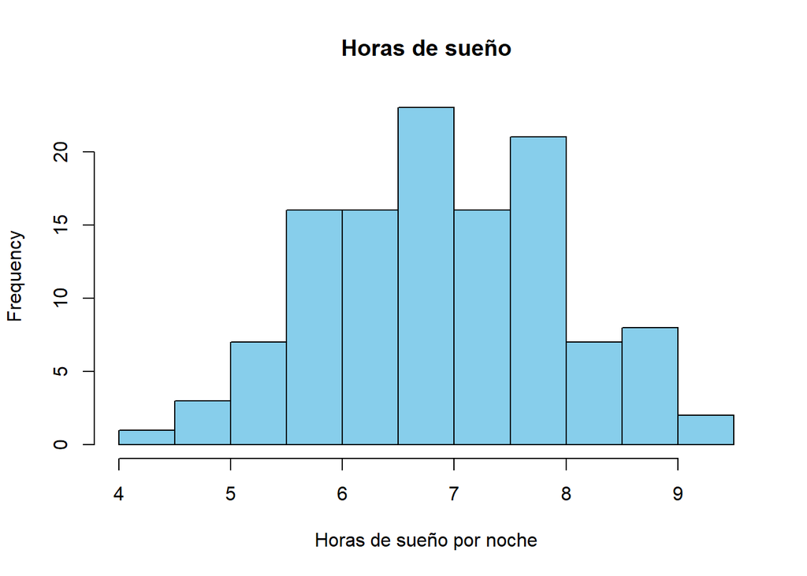

El histograma muestra que la mayoría de los estudiantes duermen entre 6 y 8 horas por noche, con una concentración especialmente alta alrededor de las 7 horas, lo cual indica una distribución aproximadamente simétrica con ligera tendencia hacia valores centrales. Hay pocos estudiantes que duermen menos de 5 horas o más de 9 horas, por lo que estos serían considerados casos menos frecuentes. En general, la variable presenta una variabilidad moderada y parece acercarse a una distribución normal.

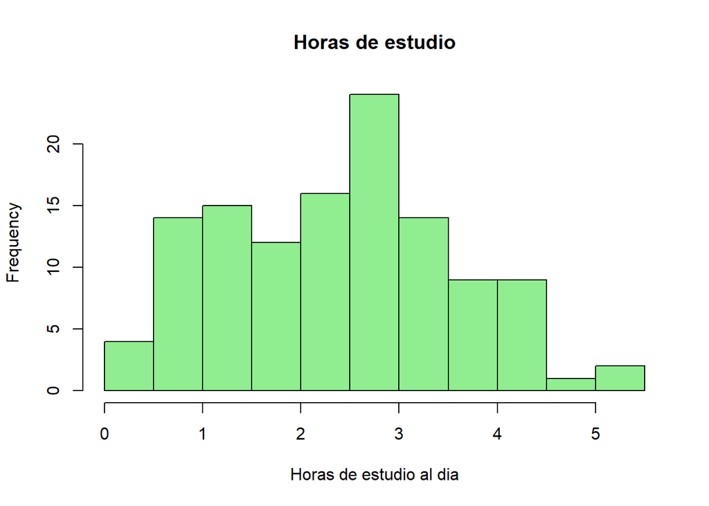

El histograma de las horas de estudio muestra una distribución ligeramente sesgada hacia la derecha, con la mayor parte de los estudiantes estudiando entre 1 y 3 horas al día. Hay menos estudiantes que reportan estudiar más de 4 horas, lo que sugiere una tendencia general hacia cargas de estudio moderadas. También se observan algunos valores muy bajos cercanos a 0, que pueden representar estudiantes con poca dedicación diaria.

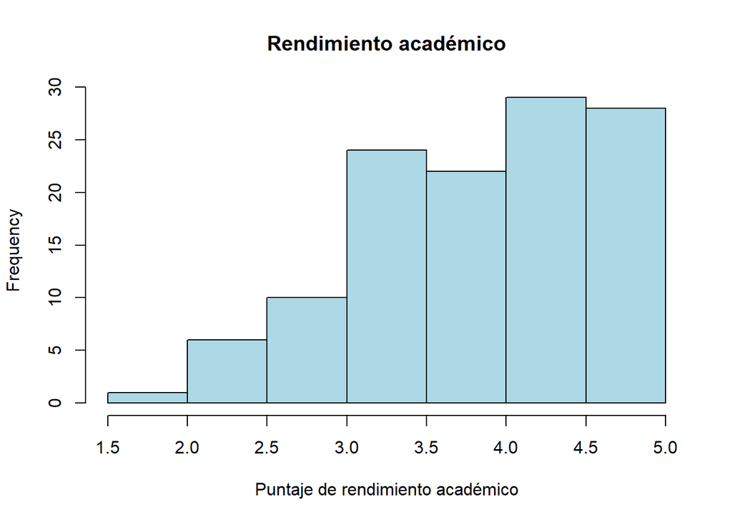

El histograma del rendimiento académico evidencia una tendencia hacia valores medios-altos, con la mayor concentración entre 3.5 y 4.8 puntos. La distribución está sesgada a la izquierda porque hay pocas notas bajas (2.0–2.5). Esto sugiere que la mayoría de estudiantes presenta un rendimiento favorable, con pocos casos extremos de bajo desempeño.

### Box-Plots

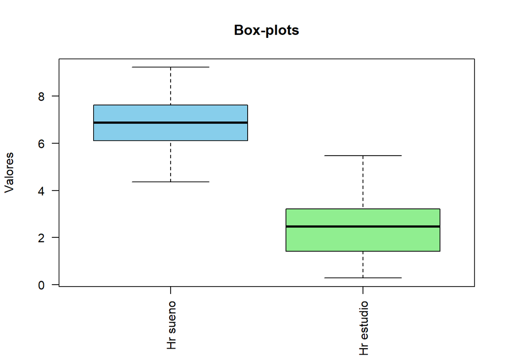

El gráfico compara la distribución de las horas de sueño y horas de estudio de los estudiantes. Se observa que las horas de sueño presentan valores más altos y menos dispersión, concentrándose mayormente entre 6 y 8 horas, lo cual indica una rutina relativamente estable. En contraste, las horas de estudio son considerablemente menores y muestran mayor variabilidad, con la mayoría de estudiantes estudiando entre 1.5 y 3 horas por día. Además, las horas de estudio exhiben un rango intercuartílico más amplio y algunos valores cercanos al mínimo, lo que sugiere diferencias más marcadas entre los hábitos de estudio de los estudiantes.

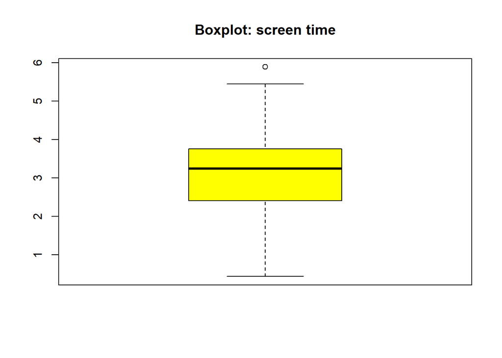

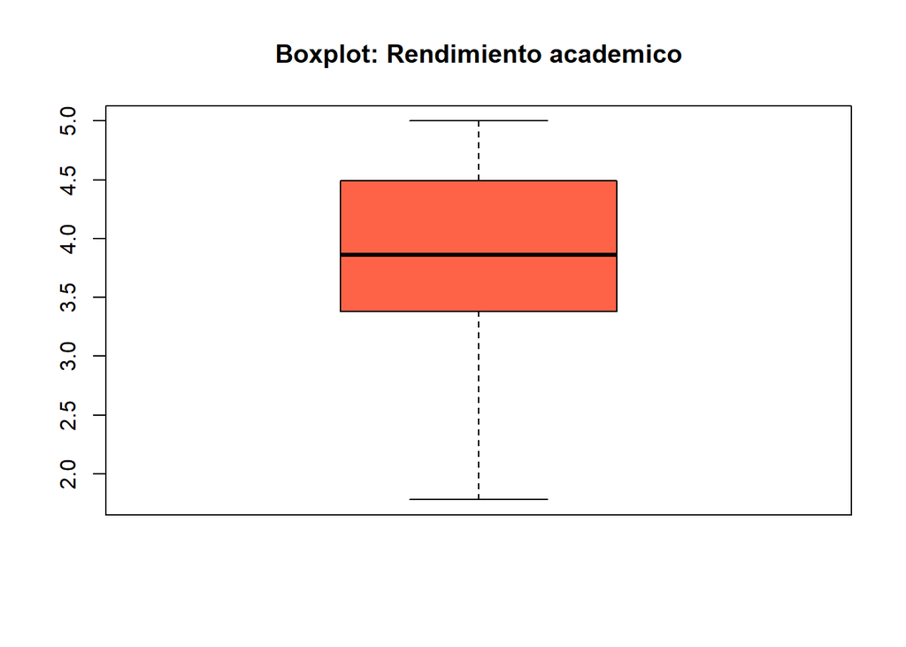

### Horas en pantalla vs rendimiento academico

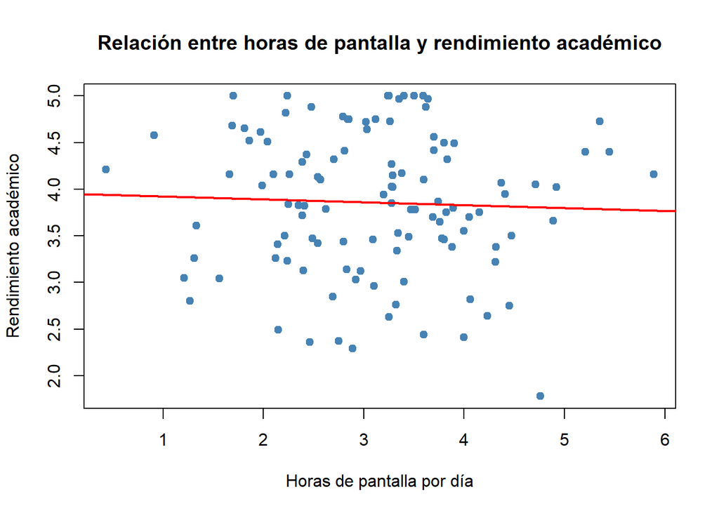

El diagrama de dispersión muestra la relación entre las horas que los estudiantes pasan frente a una pantalla y su rendimiento académico. A simple vista, los puntos se encuentran bastante dispersos, lo que indica que no existe una relación fuerte entre ambas variables. La línea roja de regresión tiene una pendiente ligeramente negativa, lo que sugiere que, en promedio, a mayor tiempo de pantalla, el rendimiento académico tiende a disminuir muy levemente, aunque el efecto es prácticamente nulo. En resumen, para esta muestra, el uso de pantallas no parece ser un factor determinante del rendimiento académico, ya que no muestra una tendencia clara ni un patrón definido.

### Horas de estudio vs rendimiento academico

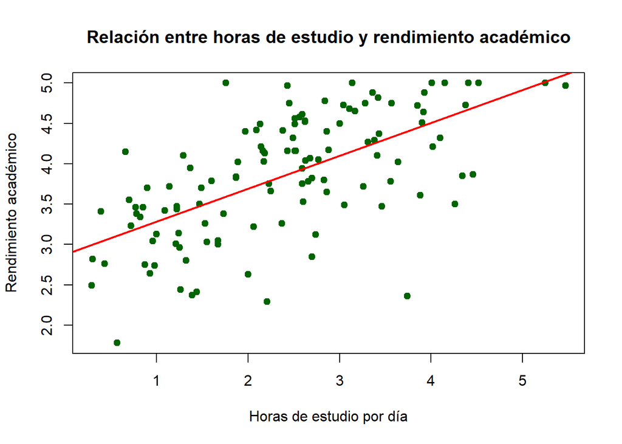

El gráfico muestra una relación positiva clara entre las horas de estudio por día y el rendimiento académico. A medida que aumentan las horas de estudio, también tienden a aumentar las calificaciones de los estudiantes. Esto se observa tanto en la dispersión de los puntos —que se agrupan hacia valores más altos de rendimiento cuando las horas de estudio son mayores— como en la línea de tendencia ascendente.

Aunque hay cierta variabilidad (estudiantes que estudian poco pero rinden bien y otros que estudian mucho pero no tanto), la tendencia general indica que estudiar más está asociado con un mejor rendimiento académico, sugiriendo que el tiempo dedicado al estudio es un factor importante en los resultados escolares.

### Horas de sueño vs rendimiento academico

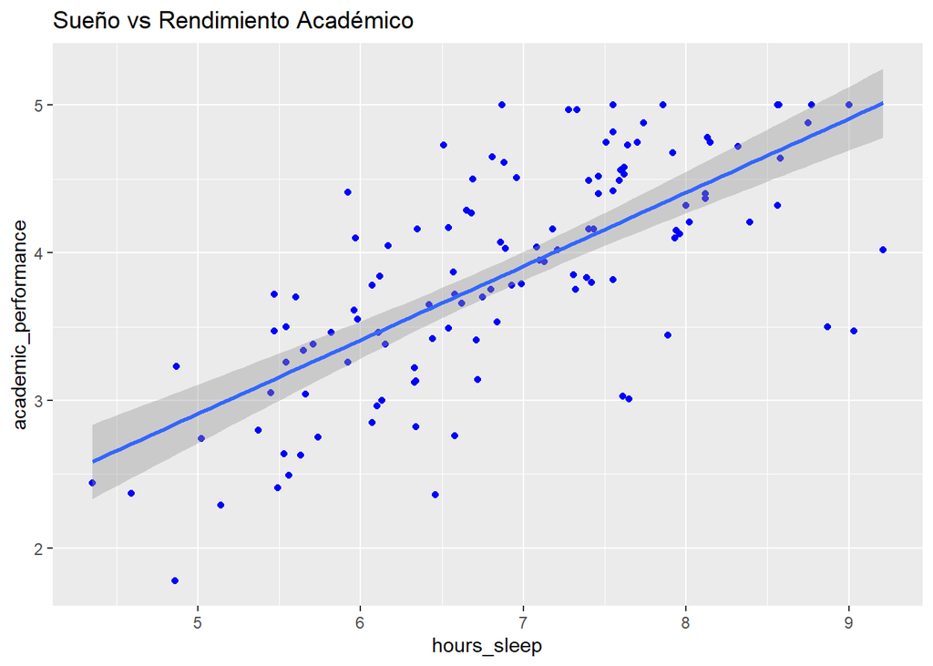

El gráfico muestra una relación positiva y bastante consistente entre las horas de sueño y el rendimiento académico: conforme los estudiantes duermen más horas por día, tienden a obtener un rendimiento académico más alto. La nube de puntos se concentra en una tendencia ascendente y la línea de regresión junto con su banda de confianza confirma que esta asociación es lineal y significativa. Aunque hay algunos valores dispersos (estudiantes que duermen poco pero obtienen buen rendimiento o viceversa), la tendencia general indica que dormir más está asociado con un mejor desempeño académico, lo cual coincide con la evidencia de que el descanso mejora la concentración, la memoria y la capacidad cognitiva.

### QQ-Plot rendimiento academico

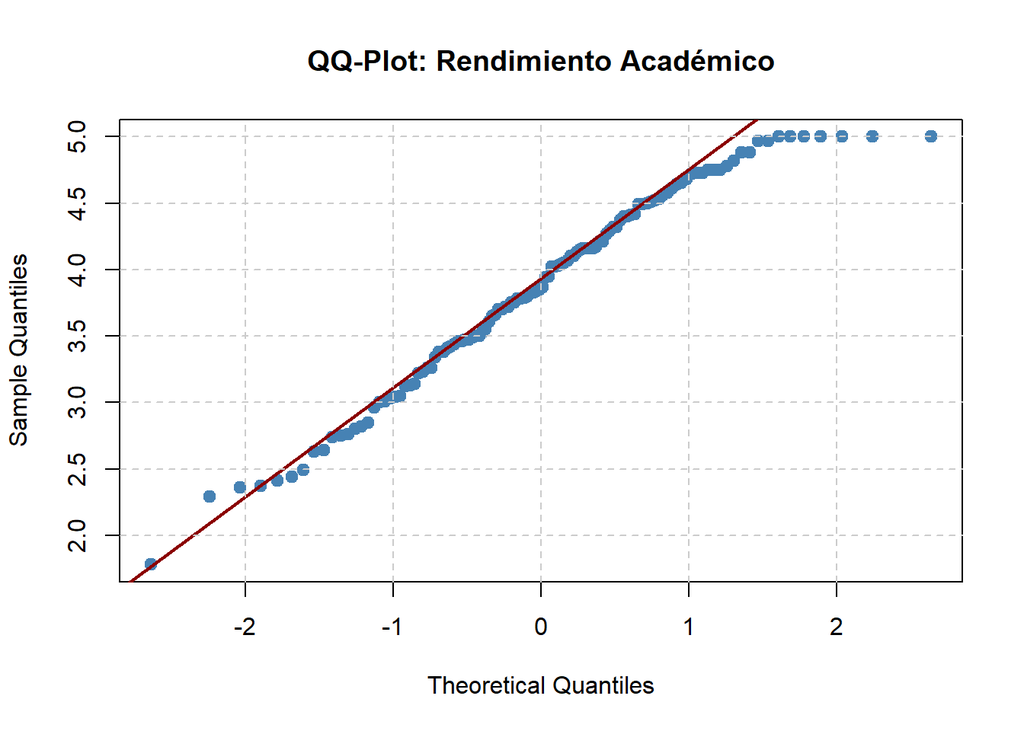

## Diseño factorial

$$Y_{ijkl} = \mu
+ \alpha_i
+ \beta_j
+ \gamma_k
+ (\alpha\beta)_{ij}
+ (\alpha\gamma)_{ik}
+ (\beta\gamma)_{jk}
+ (\alpha\beta\gamma)_{ijk}
+ \varepsilon_{ijkl},$$

```r
modelo <- aov(academic_performance ~ sleep_cat * study_cat * exercise_label,
              data = datos)
summary(modelo)
```

```
##                                     Df Sum Sq Mean Sq F value   Pr(>F)
## sleep_cat                            2 23.872  11.936  47.760 1.63e-15 ***
## study_cat                            1  6.135   6.135  24.547 2.76e-06 ***
## exercise_label                       3  7.648   2.549  10.201 5.86e-06 ***
## sleep_cat:study_cat                  1  0.141   0.141   0.564   0.4542
## sleep_cat:exercise_label             3  1.624   0.541   2.165   0.0964 .
## study_cat:exercise_label             2  0.590   0.295   1.181   0.3111
## sleep_cat:study_cat:exercise_label   1  0.348   0.348   1.393   0.2405
## Residuals                          106 26.491   0.250
## ---
## Signif. codes:  0 '***' 0.001 '**' 0.01 '*' 0.05 '.' 0.1 ' ' 1
```

### Test de shapiro-Wilk

```
##
##  Shapiro-Wilk normality test
##
## data:  res
## W = 0.97173, p-value = 0.01247
```

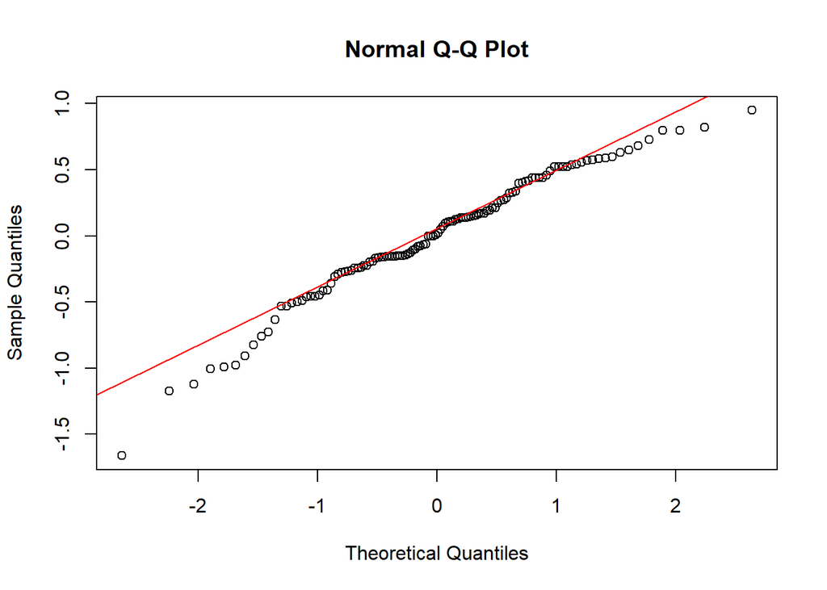

```
## Levene's Test for Homogeneity of Variance (center = median)
##        Df F value Pr(>F)
## group  13  0.8437 0.6135
##       106
```

Podemos observar que la normalidad se rechaza, por ello decidimos aplicar una transformacion box cox para poder validar este supuesto de normalidad

## Transformacion box-cox

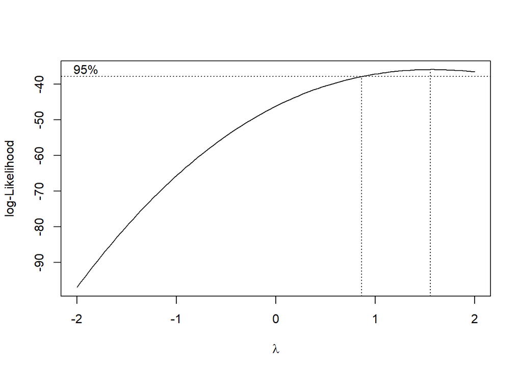

```
## [1] 1.555556
```

```
##
##  Shapiro-Wilk normality test
##
## data:  residuals(model_bc)
## W = 0.97674, p-value = 0.03555
```

```
## Levene's Test for Homogeneity of Variance (center = median)
##        Df F value Pr(>F)
## group  13  0.9202  0.535
##       106
```

Aunque el supuesto de normalidad de los residuos se rechaza tanto en el modelo original como en el transformado, la desviación es leve y ANOVA es robusto a pequeñas no-normalidades cuando el tamaño de muestra es grande, como en este caso (N ≈ 120). Además, la prueba de Levene confirma que existe homogeneidad de varianzas. Por lo tanto, el modelo factorial sin transformaciones es estadísticamente válido y se prefiere por su mayor interpretabilidad.

### Test de Tukey

```
##   Tukey multiple comparisons of means
##     95% family-wise confidence level
##
## Fit: aov(formula = academic_performance ~ sleep_cat * study_cat * exercise_label, data = datos)
##
## $sleep_cat
##                  diff        lwr        upr     p adj
## Baja-Alta  -1.3968410 -1.7647667 -1.0289153 0.0000000
## Media-Alta -0.5018653 -0.8206888 -0.1830418 0.0008612
## Media-Baja  0.8949756  0.6287376  1.1612137 0.0000000
```

```
##   Tukey multiple comparisons of means
##     95% family-wise confidence level
##
## Fit: aov(formula = academic_performance ~ sleep_cat * study_cat * exercise_label, data = datos)
##
## $study_cat
##                 diff        lwr        upr    p adj
## Bajo-Alto -0.4274791 -0.6301093 -0.2248489 5.96e-05
```

El análisis post hoc de Tukey muestra diferencias estadísticamente significativas entre varios niveles de los factores estudiados. En el caso de sleep_cat (horas de sueño categorizadas), los estudiantes del grupo Alta presentan un rendimiento académico significativamente mayor que los de los grupos Media y Baja, y asimismo el grupo Media supera al grupo Baja. Esto indica un patrón claro: a mayor categoría de horas de sueño, mejor es el rendimiento académico. Por otro lado, en el factor study_cat (horas de estudio categorizadas) se observa que los estudiantes del grupo Alto tienen un rendimiento académico significativamente superior al grupo Bajo, lo cual refuerza la importancia del tiempo de estudio. En conjunto, los resultados del post hoc confirman que tanto dormir más como estudiar más se asocian con un mejor rendimiento académico, y estas diferencias no solo son visibles en la ANOVA, sino también estadísticamente respaldadas entre los pares de grupos comparados.

## Pensamiento critico metodologico

Además, se debe considerar que los factores incluidos—horas de sueño, horas de estudio y frecuencia de ejercicio—son todos autorreporte, lo cual introduce el riesgo de sesgo de deseabilidad social o de memoria. Los estudiantes podrían sobreestimar las horas de estudio o subestimar el tiempo en pantallas para proyectar una imagen académicamente responsable. Este tipo de error puede reducir la precisión de los modelos e incluso distorsionar la magnitud real de las asociaciones entre estilos de vida y rendimiento académico.

Otra limitación importante es que el diseño del estudio es transversal, por lo que no permite inferir causalidad. Aunque se observan patrones y diferencias significativas entre niveles de sueño y estudio, no es posible afirmar que estos factores causen directamente un cambio en el rendimiento; podrían intervenir variables no consideradas, como estrés académico, calidad del sueño, hábitos de alimentación o metodologías de enseñanza.

Finalmente, el análisis se basa en categorías creadas a partir de variables continuas (baja, media, alta), lo cual facilita la interpretación pero también implica pérdida de información y posible reducción de variabilidad. En futuros estudios, sería recomendable utilizar modelos más flexibles como regresiones generalizadas, modelos mixtos, o análisis no paramétricos robustos para evitar la dependencia estricta de supuestos clásicos como normalidad o homogeneidad. Adicionalmente, un diseño longitudinal o experimental permitiría comprender con mayor precisión cómo los hábitos de vida influyen realmente sobre el rendimiento académico.

## Estado del arte

A pesar de estos avances, la literatura presenta vacíos importantes que tu análisis intenta abordar. Muchos estudios previos se concentran en una sola variable (solo sueño, o solo estudio), sin considerar la interacción conjunta entre múltiples factores dentro de un diseño factorial que permita estimar efectos combinados. Además, la mayoría de investigaciones se basan en muestras de poblaciones específicas (p. ej., estudiantes de medicina, deportistas, o adolescentes en contextos clínicos), lo cual limita la generalización. Existen también discrepancias sobre qué niveles de sueño o de estudio generan cambios significativos, lo que resalta la necesidad de análisis más integrales y comparativos. En este sentido, tu estudio aporta una contribución valiosa al explorar simultáneamente tres factores clave dentro de un modelo estadístico riguroso, identificando efectos principales y evidenciando dónde realmente existen diferencias significativas en el rendimiento académico. Esta aproximación permite llenar el vacío sobre la interacción conjunta entre hábitos de vida y desempeño académico, proporcionando una mirada más completa y aplicable al contexto universitario.

## Referencias:

- • Hillman, C. H., Erickson, K. I., & Kramer, A. F. (2008). Be smart, exercise your heart: Exercise effects on brain and cognition. Nature Reviews Neuroscience, 9(1), 58–65. https://doi.org/10.1038/nrn2298
- • Álvarez, M., & García, J. (2015). Relación entre la actividad física y el rendimiento académico en estudiantes universitarios. Revista Iberoamericana de Psicología del Ejercicio y el Deporte, 10(2), 123–135.
- • Reed, J., & Buck, T. (2009). The effect of regular aerobic exercise on positive-activated affect: A meta-analysis. Psychology of Sport and Exercise, 10(6), 581–594. https://doi.org/10.1016/j.psychsport.2009.05.009
- • Navarro, L., Gómez, A., & Pérez, R. (2020). Impacto de la actividad física regular sobre la productividad académica en estudiantes de ingeniería. Educación Física y Ciencia, 22(1), 45–59.
- • Donnelly, J. E., Lambourne, K., & Greene, A. M. (2016). Physical activity and academic achievement across the curriculum: Results from a 3-year cluster-randomized trial. Preventive Medicine, 99, 140–145. https://doi.org/10.1016/j.ypmed.2017.02.017